# Tarea1

Paulina Gómez Mont W

2/13/2019

[output not shown]

[output not shown]

[output not shown]

[output not shown]

[output not shown]

[output not shown]

Obtenemos la base de datos de los tipos de cambio.

```r
data <-read.csv("/Users/paugmw/Downloads/est46114_s06_data.csv")
#Le cambiamos el nombre  a fecha
c <- names(data)
c[1] <- "Fecha"
names(data) <- c
data[,1] <- c(1:dim(data)[1])
```

Utilizando los datos obtenemos PCA inferencial donde $\boldsymbol{\mu},\boldsymbol{\Lambda}$ son no informativas.

```r
data <- data[,2:81]

a0 <- 1
s0 <- 1
m0 <- matrix(0,ncol=1,nrow=80)
B0 <- diag(1,ncol=80,nrow=80)

gaussian.posterior <- function(data,m0,s0,a0,B0){
  xbar <- as.matrix(colMeans(data))
  S <- cov(data)
  n <- nrow(data)
  p <- ncol(data)
  # Posterior hiperparameters
  sn <- s0 + n
  an <- a0 + n/2
  mn <- (s0*m0 + n*xbar)/sn
  Bn <- B0 + (n/2)*(S + (s0/sn)*(xbar-m0)%*%t(xbar-m0))
  # Output
  output <- list(mn,sn,an,Bn)
  return(output)
}

output <- gaussian.posterior(data,m0,s0,a0,B0)


M <- 10000
mu.sim <- matrix(NA,nrow=M, ncol=ncol(data))
Lambda.sim <- array(NA,dim=c(M,ncol(data),ncol(data)))
e.sim <- matrix(NA,nrow=M, ncol=ncol(data))
V.sim <- array(NA,dim=c(M,ncol(data),ncol(data)))
C.sim <- array(NA,dim=c(M,nrow(data),ncol(data)))
m <- 1
X <- as.matrix(data)
for(m in 1:M){
  # Simulacion (mu,Lambda)
  Lambda.sim[m,,] <- rWishart(1, output[[3]], output[[4]])
  mu.sim[m,] <- mvrnorm(1, mu=output[[1]], Sigma=solve(output[[2]]*Lambda.sim[m,,]), tol = 1e-6)
  # Simulacion (e,V) + C
  eigen_aux <- eigen(solve(Lambda.sim[m,,]))
  e.sim[m,] <- eigen_aux$values
  V.sim[m,,] <- eigen_aux$vectors
  C.sim[m,,] <- X %*% V.sim[m,,]
}
```

Usando las medias de los eigenvalores, vemos que porcentaje de la varianza explica cada eiegenvalor, podemos ver que el primer eiegnvector explica solo aproximadamente el 8% de la varianza de los datos. Tendríamos que usar al menos los primeros 10 eiegenvalores para explicar aproximadamente 50% de la varianza de los datos

```r
eieg_me <- c(rep(0,dim(e.sim)[2]))
eieg_me_var <- c(rep(0,dim(e.sim)[2]))
for(i in 1:dim(e.sim)[2]){
  eieg_me[i] <- mean(e.sim[,i])
}
for(i in 1:dim(e.sim)[2]){
  eieg_me_var[i] <- eieg_me[i]/sum(eieg_me)
}
eieg_me_var[1]
```

```
## [1] 0.07768259
```

```r
sum(eieg_me_var[1:10])
```

```
## [1] 0.5496109
```

Ahora si analisamos las medias obtenidas con las simulaciones para obtener las medias de los eigenvectores. Y podemos ver el impacto estimado por cada país, sin embargo como obsrevamos anteriormente el eiegnvector 1 sólo explica ~8% de la varianza.

```r
eiegv_me <- matrix(rep(0,80*80),nrow=80,ncol=80)
eiegv_me_var <- matrix(rep(0,80*80),nrow=80,ncol=80)
for(m in 1:80){
  for(i in 1:80){
  eiegv_me[m,i] <- mean(V.sim[,m,i])
  }
}
for(i in 1:80){
  for(j in 1:80){
    eiegv_me_var[i,j] <- eiegv_me[i,j]/sum(eiegv_me[,j])
    }

}

eiegv_me[,1]
```

```
##  [1] -2.280090e-03 -1.930436e-06 -1.244708e-04  2.620474e-05  5.021018e-05
##  [6]  1.298910e-05  1.032602e-06 -5.361182e-04  1.987278e-05 -4.674250e-06
## [11] -2.452733e-04 -1.265408e-06 -1.276210e-04  3.591105e-08 -1.236163e-07
## [16] -1.171698e-06  5.064625e-04  1.440564e-07 -3.979649e-06  1.147834e-04
## [21] -4.324899e-03  1.025670e-05  1.239821e-05 -2.430638e-03 -1.224495e-03
## [26]  4.927216e-04  1.711643e-03  3.090330e-03 -7.299249e-04  2.086235e-04
## [31]  2.467480e-03  1.401983e-03  1.261168e-04  3.219617e-06  1.649017e-04
## [36] -5.714398e-05 -7.889720e-07  2.099163e-03 -1.639257e-03  2.057301e-03
## [41] -2.881737e-03  4.474203e-04  1.102576e-05 -2.138037e-04  1.782658e-03
## [46] -3.782374e-03 -4.124420e-05 -1.214579e-05 -2.434100e-06 -2.388996e-05
## [51]  2.084070e-05  1.250250e-05 -5.180519e-04  2.312525e-03 -2.628198e-08
## [56]  8.425173e-06 -1.115007e-04  7.434225e-07 -1.559966e-04 -3.754829e-05
## [61]  1.513014e-05 -8.340104e-04  3.539767e-04  2.379500e-04 -2.178821e-05
## [66]  1.486040e-03  3.940586e-05 -5.900343e-07  6.237513e-06  4.046194e-07
## [71] -2.048295e-06  1.774266e-03 -5.361255e-06 -4.389885e-07 -1.761901e-06
## [76]  4.032854e-06 -3.454098e-07 -4.137321e-05  1.526145e-04 -1.540692e-09
```

```r
eiegv_me_var[,1]
```

```
##  [1] -2.774721e+00 -2.349215e-03 -1.514729e-01  3.188947e-02  6.110253e-02
##  [6]  1.580689e-02  1.256610e-03 -6.524211e-01  2.418389e-02 -5.688259e-03
## [11] -2.984817e-01 -1.539919e-03 -1.553064e-01  4.370142e-05 -1.504330e-04
## [16] -1.425880e-03  6.163320e-01  1.753073e-04 -4.842974e-03  1.396840e-01
## [21] -5.263121e+00  1.248174e-02  1.508782e-02 -2.957929e+00 -1.490131e+00
## [26]  5.996102e-01  2.082958e+00  3.760731e+00 -8.882712e-01  2.538812e-01
## [31]  3.002763e+00  1.706122e+00  1.534760e-01  3.918065e-03  2.006747e-01
## [36] -6.954051e-02 -9.601277e-04  2.554546e+00 -1.994870e+00  2.503602e+00
## [41] -3.506887e+00  5.444815e-01  1.341763e-02 -2.601853e-01  2.169380e+00
## [46] -4.602903e+00 -5.019151e-02 -1.478064e-02 -2.962142e-03 -2.907253e-02
## [51]  2.536177e-02  1.521473e-02 -6.304355e-01  2.814193e+00 -3.198347e-05
## [56]  1.025289e-02 -1.356891e-01  9.046970e-04 -1.898378e-01 -4.569383e-02
## [61]  1.841240e-02 -1.014936e+00  4.307666e-01  2.895697e-01 -2.651483e-02
## [66]  1.808414e+00  4.795437e-02 -7.180335e-04  7.590649e-03  4.923956e-04
## [71] -2.492642e-03  2.159166e+00 -6.524299e-03 -5.342204e-04 -2.144119e-03
## [76]  4.907722e-03 -4.203413e-04 -5.034851e-02  1.857219e-01 -1.874923e-06
```

```r
max(abs(eiegv_me_var[,1]))
```

```
## [1] 5.263121
```

Por otro lado, en la grádica inferior podemos ver como se ven la Series de Tiempo de cada Tipo de Cambio, aunque algunas series se ven estables unas se ve que tienen tendencia (no son estacionarias).

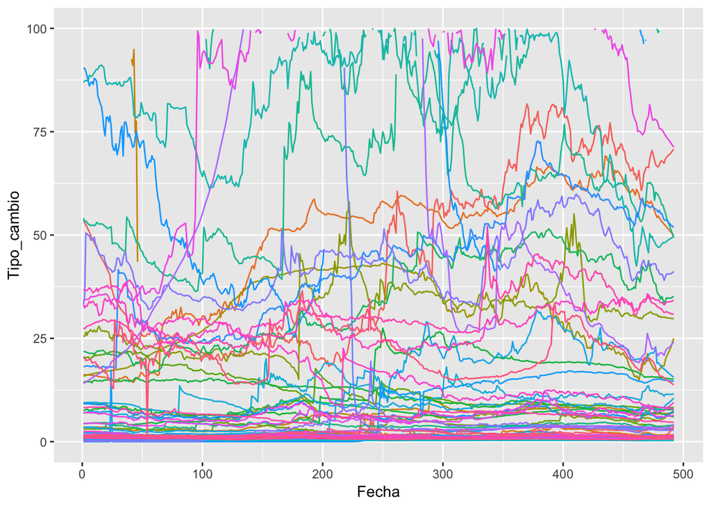

```r
data <-read.csv("/Users/paugmw/Downloads/est46114_s06_data.csv")
#Le cambiamos el nombre  a fecha
c <- names(data)
c[1] <- "Fecha"
names(data) <- c
data[,1] <- c(1:dim(data)[1])
data_g <- data %>% gather(
  key="Pais",
  value=Tipo_cambio,
  -Fecha
)
ggplot(data_g)+geom_line(aes(x=Fecha,y=Tipo_cambio,colour=Pais),show.legend = FALSE)+ylim(c(0,100))
```

Haremos una transformación de los datos para ver si obtenemos mejores resultados si obtenemos el PCA inferencial sobre los retornos de los tipos de cambios.

```r
data <-read.csv("/Users/paugmw/Downloads/est46114_s06_data.csv")
#Le cambiamos el nombre  a fecha
c <- names(data)
c[1] <- "Fecha"
names(data) <- c
data[,1] <- c(1:dim(data)[1])
data <- data[,2:81]
retornos <- matrix(rep(0,80*(dim(data)[1]-1)),ncol=80,nrow=(dim(data)[1]-1))
for(i in 1:80){
  for(j in 1:(dim(data)[1]-1)){
    retornos[j,i] <- log(data[j+1,i]/data[j,i])
  }
}
```

Trate de utilizar los retornos obtenemos PCA inferencial donde $\boldsymbol{\mu},\boldsymbol{\Lambda}$ son no informativas, pero la matriz rWishart es no positiva definida entonces no pude seguir.

```r
data <- retornos

a0 <- 1
s0 <- 1
m0 <- matrix(0,ncol=1,nrow=80)
B0 <- diag(1,ncol=80,nrow=80)

gaussian.posterior <- function(data,m0,s0,a0,B0){
  xbar <- as.matrix(colMeans(data))
  S <- cov(data)
  n <- nrow(data)
  p <- ncol(data)
  # Posterior hiperparameters
  sn <- s0 + n
  an <- a0 + n/2
  mn <- (s0*m0 + n*xbar)/sn
  Bn <- B0 + (n/2)*(S + (s0/sn)*(xbar-m0)%*%t(xbar-m0))
  # Output
  output <- list(mn,sn,an,Bn)
  return(output)
}

output <- gaussian.posterior(data,m0,s0,a0,B0)


M <- 10000
mu.sim <- matrix(NA,nrow=M, ncol=ncol(data))
Lambda.sim <- array(NA,dim=c(M,ncol(data),ncol(data)))
e.sim <- matrix(NA,nrow=M, ncol=ncol(data))
V.sim <- array(NA,dim=c(M,ncol(data),ncol(data)))
C.sim <- array(NA,dim=c(M,nrow(data),ncol(data)))
m <- 1
X <- as.matrix(data)
# for(m in 1:M){
#   # Simulacion (mu,Lambda)
#   Lambda.sim[m,,] <- rWishart(1, output[[3]], output[[4]])
#   mu.sim[m,] <- mvrnorm(1, mu=output[[1]], Sigma=solve(output[[2]]*Lambda.sim[m,,]), tol = 1e-6)
#   # Simulacion (e,V) + C
#   eigen_aux <- eigen(solve(Lambda.sim[m,,]))
#   e.sim[m,] <- eigen_aux$values
#   V.sim[m,,] <- eigen_aux$vectors
#   C.sim[m,,] <- X %*% V.sim[m,,]
# }
```